# Classification - Part 1

Evan Batzer

September 3, 2018

# Clustering Communities - How best to define different states?

There are a number of different algorithms that can be used in cluster analysis, ranging from hierarchical, agglomerative methods that have been (in my impression) a mainstay in Ecology, to more computationally intensive or statistically nuanced methods, such as K-means (and its variations) or model-based clustering.

Based on my reading, there is no simple way to determine what type of algorithm is best suited to your needs, or how many clusters are appropriate. According to Legendre and Legendre (2008), all methods are valid, save for TWINSPAN, which is cautioned against. If using K-means or hierarchical methods, there are some heuristics that can be used to identify the appropriate amount of clusters needed in the data. Model-based clustering is more complicated, but offers standard metrics to compare model fits – typically, Bayesian Information Criterion (BIC).

I think the best way to choose an appropriate classification algorithm is to explore a number of possibilities. Stein et al. (2016) and Bagchi et al. (2013) both employ hierarchical clustering algorithms - flexible beta and Ward’s D, respectively - but we may have better luck using a method like K-means or one of the model-based clusters.

Some key considerations:

- **How to transform data prior to analysis?** I think in most cases, focusing on the proportional abundance of species in each sample makes the most sense, but there may be some validity to using one of the other recommended transformations, such as Hellinger or Chi-Square.
- **What distance metric to use?** Most ecological data utilizes Bray-Curtis or Euclidean distances between communities with abundance data. Bray-Curtis has a number of poor mathematical properties, however, that may make its use problematic in some circumstances. Horn and Morisita-Horn indices may be better, but are more suited to individual counts an are less often used in circumstances with cover data.
- **When to start clustering?** The seeded communities contain a number of species that are not well-represented in the data after the first year of planting. While this is interesting information, it can be problematic for clustering, as it may make the first year of data really distinct, almost a separate cluster in itself. My guess is that Stein et al. (2016) found that this was the case with their data - they had 5 years of data in their study, but appeared to only run classification and NMDS on the last 4 years.
- **What species to include in analyses?** When trying to cluster communities, most analyses are conducted on either a relevant subset of species or a modified dataset. Stein et al. (2016) combine all of their weedy species / forbs into a single column called “forbs”, while Bagchi et al. (2013) focus on species that occur in at least 2% of all samples taken. There are a lot of weedy species in the WAPS data that could be ignored in clustering as “noise”.
  - **Here, I’ve only included non-agricultural weeds in my analysis, which represents roughly 93% of the total cover in the dataset**

```
## [1] "Total Cover in Dataset:"
```

```
##                  avena                 elymus           taeniatherum
##               22554.50               20981.50               18669.00
##               aegilops           bro.diandrus        bro.hordeaceous
##               12611.00               11665.00                9430.00
##                 lolium          bro.carinatus                  vicia
##                6855.00                5946.50                5907.50
##               nassella                 leymus              trifolium
##                4785.00                3352.50                3310.00
##                lupinus                  lotus                 vulpia
##                3007.50                1534.00                1250.25
##               bindweed               geranium       lactuca.serriola
##                 897.50                 837.50                 720.00
##                mustard                senecio                 conyza
##                 585.00                 442.50                 340.00
##      erodium.moschatum             hordeum.sp        kickxia.elatine
##                 297.50                 170.00                 110.00
##                con.arv            unk.thistle                    poa
##                  90.00                  90.00                  82.50
##              centaurea                redmaid             helianthus
##                  42.50                  25.00                  12.50
##          orchard.grass tragopogon.porrifolius               veronica
##                  12.50                  12.50                  12.50
##            phalaris.sp                cap.bur        epilobium.brach
##                   5.00                   2.50                   2.50
##        bro.madritensis                   oats             bunchgrass
##                   0.00                   0.00                   0.00
##                 ag.big               ag.small              amsinckia
##                   0.00                   0.00                   0.00
##     big.leaf.dandelion                 galium               gumplant
##                   0.00                   0.00                   0.00
##        italian.thistle              melilotus           milk.thistle
##                   0.00                   0.00                   0.00
##                tarweed                thistle
##                   0.00                   0.00
```

```
## [1] "Plot Occupancy in Dataset:"
```

```
##                  avena                 elymus           taeniatherum
##                   0.64                   0.54                   0.46
##               aegilops        bro.hordeaceous          bro.carinatus
##                   0.45                   0.44                   0.29
##                 lolium           bro.diandrus               nassella
##                   0.28                   0.27                   0.23
##                  vicia                 leymus              trifolium
##                   0.21                   0.14                   0.12
##                lupinus                  lotus                 vulpia
##                   0.09                   0.08                   0.07
##               bindweed                 conyza               geranium
##                   0.07                   0.04                   0.03
##       lactuca.serriola                mustard             hordeum.sp
##                   0.03                   0.03                   0.02
##      erodium.moschatum                senecio                    poa
##                   0.02                   0.02                   0.01
##        bro.madritensis                   oats              centaurea
##                   0.00                   0.00                   0.00
##             bunchgrass                 ag.big               ag.small
##                   0.00                   0.00                   0.00
##              amsinckia     big.leaf.dandelion                cap.bur
##                   0.00                   0.00                   0.00
##                con.arv        epilobium.brach                 galium
##                   0.00                   0.00                   0.00
##               gumplant             helianthus        italian.thistle
##                   0.00                   0.00                   0.00
##        kickxia.elatine              melilotus           milk.thistle
##                   0.00                   0.00                   0.00
##          orchard.grass            phalaris.sp                redmaid
##                   0.00                   0.00                   0.00
##                tarweed                thistle tragopogon.porrifolius
##                   0.00                   0.00                   0.00
##            unk.thistle               veronica
##                   0.00                   0.00
```

```
## Fraction of total cover contained in subset = 0.9275175
```

# Visualizing Data:

The first step in this analysis is to visualize the data using some sort of unconstrained ordination method. Because I’ll be using Bray-Curtis distance to describe differences between points, NMDS seems to be the best option.

Below, I show an NMDS plot of all community datapoints, colored by year. I believe that I’ve sent these graphs along before – the basic gist I get from this figure is that communities aren’t particularly stable.

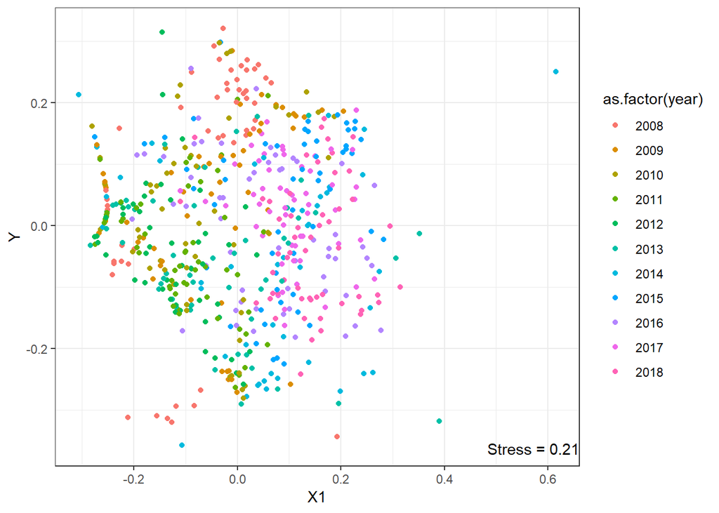

# K-means Clustering

To be able to quantitatively assess differences between communities when there isn’t a clear pattern with simple similarity metrics, clustering methods may ease comparison. In this method, rather than looking at distances between communities, we can compare changes in community composition as movement between discrete states.

Here, I’m employing K-means clustering, one method that attempts to partition datasets into some “K” number of cluster types. One nice feature of this method is that the optimal number of clusters can be determined by a number of different metrics.

## Selecting an appropriate number of clusters

Here, I utilize a package called NbClust() that can be used to implement a number of different metrics – the nbclust() package in R suggests using a battery of tests to see if some cluster number appears as a consistent good performer.

When comparing a number of different criteria, 4 seems to be the best number of clusters to use (see best.nc table, which highlights the best performer for each type of metric). 4 clusters is selected as the best number in 4 of the 8 metrics, and consistently performs well (usually in the top 2-4 of the 10) for the rest.

Apparently, 7 clusters also seems like a good second choice by these metrics, though that number seems too high to be relevant given the number of replicates we have, as well as my intuition for the system as a whole.

```
## $All.index
##    Hartigan       CH   Beale     KL Cindex     DB Silhouette   Duda
## 2  133.8844 163.1036  2.7007 1.2204 0.4969 1.6900     0.2127 0.8219
## 3  128.5555 166.1493  1.9561 1.1244 0.4548 1.5923     0.2342 0.8642
## 4   52.2528 176.7473 -2.0175 3.0871 0.4159 1.4855     0.2606 1.1936
## 5   69.9999 156.7762  5.4132 0.6982 0.4027 1.4177     0.2732 0.6967
## 6   84.3601 153.6546 -2.0313 0.8687 0.3631 1.4765     0.2955 1.1959
## 7   28.8838 159.6955  1.1190 3.8277 0.3640 1.4027     0.3040 0.9172
## 8   63.5405 147.3097 -3.1166 0.3883 0.3138 1.4978     0.2740 1.3385
## 9   48.7758 150.1714 -2.0585 1.4206 0.3316 1.4702     0.2909 1.2009
## 10  25.5711 149.4719 -9.3346 2.2367 0.3172 1.4170     0.2820 4.1963
##
## $Best.nc
##                 Hartigan       CH   Beale     KL Cindex     DB Silhouette
## Number_clusters   4.0000   4.0000  4.0000 7.0000 8.0000 7.0000      7.000
## Value_Index      76.3026 176.7473 -2.0175 3.8277 0.3138 1.4027      0.304
##                   Duda
## Number_clusters 4.0000
## Value_Index     1.1936
```

## Visualizing how the clustering algorithm splits up the data

```
##     build      swap
## 0.4494200 0.4229383
```

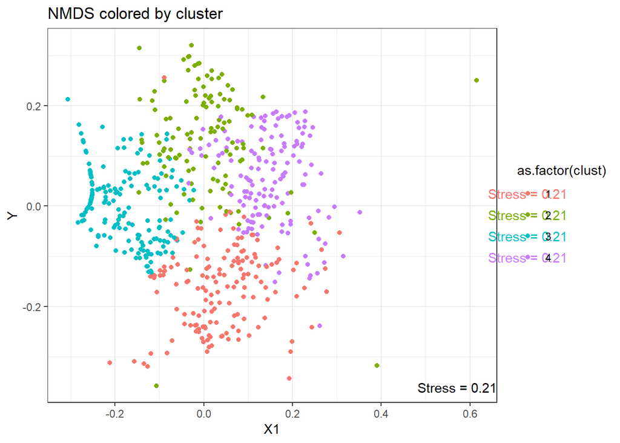

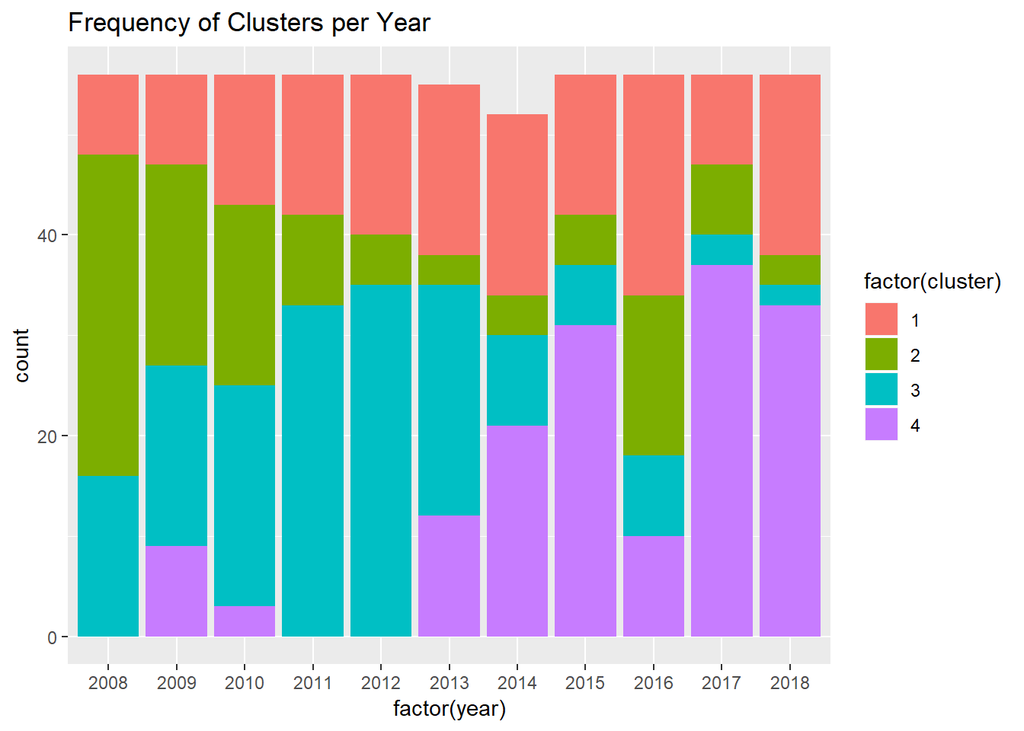

# Describing clusters:

## Indicator species analysis:

What defines each cluster? The few papers I have seen describing this method have used indicator species analysis to determine what defines each group – I’ve done the same below:

```
##
##  Multilevel pattern analysis
##  ---------------------------
##
##  Association function: IndVal.g
##  Significance level (alpha): 0.05
##
##  Total number of species: 18
##  Selected number of species: 13
##  Number of species associated to 1 group: 13
##  Number of species associated to 2 groups: 0
##  Number of species associated to 3 groups: 0
##
##  List of species associated to each combination:
##
##  Group 1  #sps.  4
##                stat p.value
## elymus        0.801   0.001 ***
## nassella      0.574   0.001 ***
## bro.carinatus 0.548   0.001 ***
## vulpia        0.284   0.001 ***
##
##  Group 2  #sps.  3
##                  stat p.value
## lolium          0.825   0.001 ***
## bro.hordeaceous 0.723   0.001 ***
## trifolium       0.607   0.001 ***
##
##  Group 3  #sps.  2
##               stat p.value
## taeniatherum 0.871   0.001 ***
## aegilops     0.741   0.001 ***
##
##  Group 4  #sps.  4
##               stat p.value
## avena        0.819   0.001 ***
## bro.diandrus 0.553   0.001 ***
## leymus       0.303   0.036 *
## lotus        0.274   0.011 *
## ---
## Signif. codes:  0 '***' 0.001 '**' 0.01 '*' 0.05 '.' 0.1 ' ' 1
```

The four groups defined seem to indicate the presence of a few different species groups that I’ve roughly defined as the following:

1. Native species
2. “Wet annuals” – those annuals that seemed to do best early in the experiment, either driven by wetter temperatures or priority effects.
3. “WAPS”
4. “Dry annuals” – those annuals that seemed to do best later in the experiment, perhaps driven by drier weather.

## Visualizing differences

What constitutes each group? The easiest way to do so might be a simple pie chart:

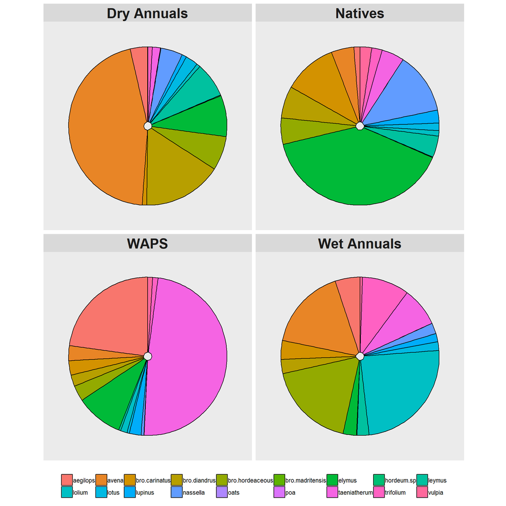

# Plotting transitions between clusters over time

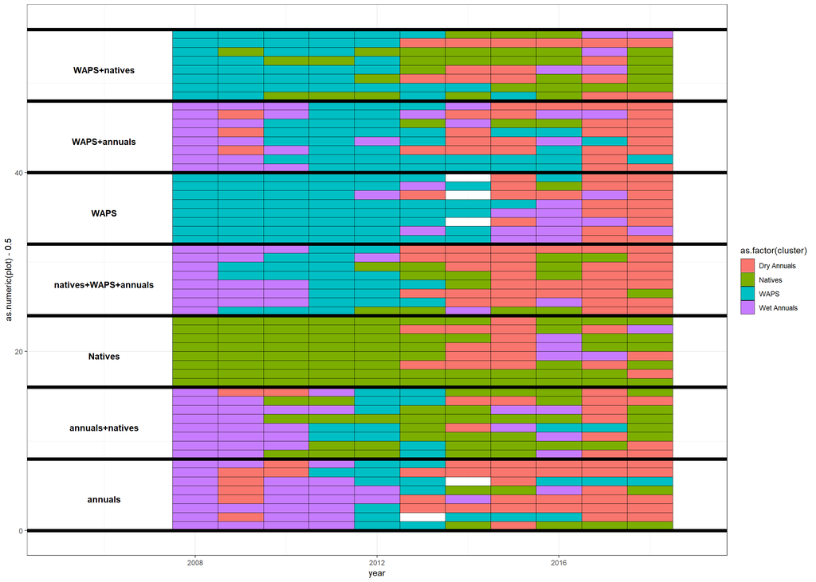

# Frequency of transitions

How often do transitions occur? The above figures show that there are some general patterns in transition frequency and directionality of change. It seems that transitions to WAPS are the most frequent early in the experiment, but many groups transition to a “dry annuals” state following the drought.

To assess this qualitatively, I’ve included some figures with transition frequency + direction plotted with precipitation.

In the first figure, total annual precipitation (relative) is plotted as a black line above the plot.

In the second, total precipitation, early (Oct - Dec, blue line), middle (Jan - Mar, orange line), and late (April - May, red line) precip are plotted as separate lines above the bars.

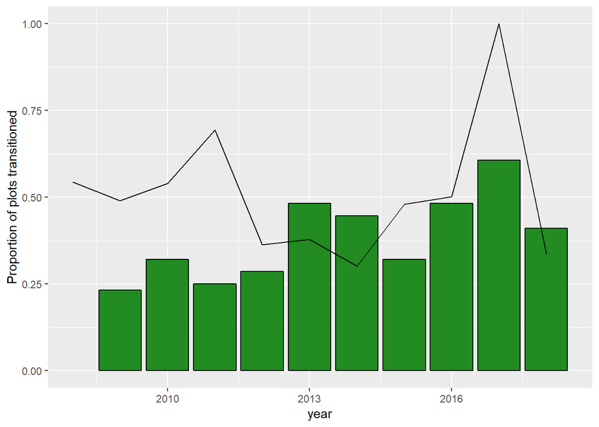

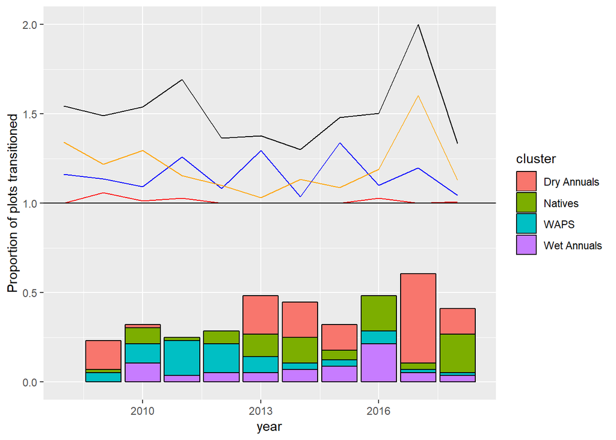